# Análisis Avanzado de Datos - Taller 2

**Felipe Sarmiento & Juan S. Henao**

# 1. Problema 1 - 80pt

En este ejericio realizaremos una comparación de diferentes paradigmas de modelamiento y determinaremos cúal de ellos tiene mejor desempeño utilizando validación cruzada y medición del error cuadratico medio.

## 1.1 Separación Aleatoria

Iniciaremos separando aleatoriamiente el conjunto de datos (90/10).

```r
knitr::opts_chunk$set(warning = FALSE)
knitr::opts_chunk$set(fig.width = 8, fig.height = 6)
```

```r
library(ISLR2)
library(ggplot2)
library(ggthemes)
library(wesanderson)
library(caret)
library(splines)
library(caret)
library(ggplot2)
library(gt)
library(tidyverse)
# Cargar el conjunto de datos Auto
data(Auto)

# Establecer una semilla para la división de datos aleatoria
set.seed(42)

# Dividir los datos en conjuntos de entrenamiento y prueba
sample_size <- floor(0.9 * nrow(Auto))
train_indices <- sample(seq_len(nrow(Auto)), size = sample_size)

train_data <- Auto[train_indices, ]
test_data <- Auto[-train_indices, ]
```

Hemos dividido el dataset en train (352 observaciones) y test (40 observaciones), ahora iniciaremos creando algunas visualizaciones y estadísticas de resumen para explorar el conjunto de datos. Nos centraremos en la relación entre caballos de fuerza y mpg.

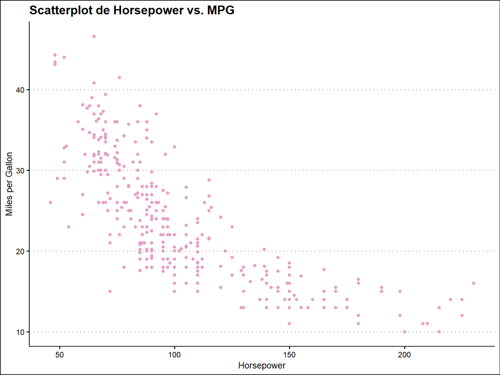

```r
# Gráfico de dispersión de horsepower vs. mpg
  ggplot(train_data, aes(x = horsepower, y = mpg)) +
  geom_point(color = wes_palette("GrandBudapest2", 1, type = "continuous")) +
  ggtitle("Scatterplot de Horsepower vs. MPG") +
  xlab("Horsepower") +
  ylab("Miles per Gallon") +
  theme_clean()
```

**1.1 Relación inversa:** el gráfico muestra una relación inversa entre la potencia y las millas por galón, lo que indica que a medida que aumenta la potencia de un vehículo, su rendimiento en términos de millas por galón tiende a disminuir. Esto sugiere que los vehículos con motores más potentes consumen más combustible.

**1.2 Patrón no lineal:** La relación entre la potencia y las millas por galón parece ser no lineal, lo que indica que la tasa de cambio en la eficiencia del combustible no es constante a medida que aumenta la potencia. Podría haber ciertos rangos de potencia donde la eficiencia del combustible disminuye más rápidamente que en otros rangos.

**1.3 Variabilidad:** A pesar de la relación general entre la potencia y las millas por galón, hay cierta variabilidad en los datos, lo que sugiere que existen otros factores que también pueden influir en la eficiencia del combustible, como el peso del vehículo, el desplazamiento del motor y las características del diseño.

```r
summary_stats <- train_data %>%
  select_if(is.numeric) %>%
  summarise_all(list(min = min, max = max, mean = mean, median = median, sd = sd)) %>%
  pivot_longer(cols = everything(), names_to = "Statistic", values_to = "Value") %>%
  separate(col = Statistic, into = c("Variable", "Statistic"), sep = "_") %>%
  pivot_wider(names_from = "Statistic", values_from = "Value")

# Load DT package
library(DT)

# Create a DT table
datatable(summary_stats,
          options = list(pageLength = 10, lengthMenu = c(5, 10, 20, 50)),
          rownames = FALSE,
          caption = "Estadísticos de resumen para el Dataset Auto") %>%
  formatRound(columns = c("min", "max", "mean", "median", "sd"), digits = 2)
```

| Variable | min | max | mean | median | sd |
| --- | --- | --- | --- | --- | --- |
| mpg | 10 | 46.6 | 23.3965909090909 | 22 | 7.74490659004859 |
| cylinders | 3 | 8 | 5.47159090909091 | 4 | 1.70111067211323 |
| displacement | 68 | 455 | 194.572443181818 | 151 | 103.827394881683 |
| horsepower | 46 | 230 | 104.139204545455 | 92.5 | 38.2933711794682 |
| weight | 1613 | 5140 | 2974.50852272727 | 2811 | 838.376480129469 |
| acceleration | 8 | 24.8 | 15.6079545454545 | 15.5 | 2.81360032722254 |
| year | 70 | 82 | 75.9943181818182 | 76 | 3.67713681365477 |
| origin | 1 | 3 | 1.5625 | 1 | 0.799973290152406 |

**1.1 conclusiones sobre las estadisticas de resumen:**

- La variabilidad significativa en el rendimiento de millas por galón (mpg) sugiere que existen múltiples factores, como el peso, la potencia y el desplazamiento, que influyen en la eficiencia del combustible de los vehículos.
- La amplia dispersión en el desplazamiento y la potencia de los vehículos indica una diversidad en las capacidades de rendimiento y, posiblemente, en las preferencias de los consumidores, lo que podría tener un impacto en la eficiencia del combustible y la aceleración de los vehículos.
- El análisis de cómo han cambiado las características y el rendimiento de los vehículos a lo largo del tiempo, en función del año de fabricación, podría proporcionar información sobre las tendencias en la eficiencia del combustible y otros atributos importantes

## 1.2 Regresión Spline

Mediante validación cruzada en 10 folds, determinaremos el número óptimo de knots para el problema de regresión spline

```r
#Semilla y número de folds
fold <- 10
seed <- 42

# Función para calcular el ECM para un modelo de regresión
calculate_ecm <- function(train_data, num_knots, fold, seed) {
  set.seed(seed)
  train_index <- createFolds(train_data$mpg, k = fold, list = TRUE, returnTrain = TRUE)
  ecm_values <- numeric(fold)

  for (i in 1:fold) {
    train_fold <- train_data[train_index[[i]], ]
    test_fold <- train_data[-train_index[[i]], ]

    knots <- seq(min(train_fold$horsepower), max(train_fold$horsepower), length.out = num_knots + 2)[-c(1, num_knots + 2)]
    spline_model <- lm(mpg ~ bs(horsepower, knots = knots, degree = 3), data = train_fold)
    predictions <- suppressWarnings(predict(spline_model, test_fold))
    ecm_values[i] <- mean((test_fold$mpg - predictions)^2)
  }

  return(mean(ecm_values))
}

# Definir num_knots_range con 10 valores posibles
num_knots_range <- 1:10


# Realizar la validación cruzada en 10 folds para cada cantidad de knots
ecm_num_knots <- suppressWarnings(sapply(num_knots_range, function(num_knots) calculate_ecm(train_data, num_knots, 10, seed)))

# Determinar el modelo con el menor ECM de predicción
best_num_knots <- num_knots_range[which.min(ecm_num_knots)]
best_ecm <- min(ecm_num_knots)
# Crear un data.frame con los valores de knots y sus correspondientes ECM
mse_table <- data.frame(Knots = num_knots_range, ECM = ecm_num_knots)

# Creación de la tabla
beautiful_mse_table <- mse_table

# Create an interactive table
datatable(beautiful_mse_table,
          options = list(pageLength = 10, lengthMenu = c(5, 10, 20, 50)),
          rownames = FALSE,
          caption = "ECM por cantidad de knots") %>%
  formatRound(columns = "ECM", digits = 2)
```

| Knots | ECM |
| --- | --- |
| 1 | 19.6902571750616 |
| 2 | 19.5709263852617 |
| 3 | 19.5168874919172 |
| 4 | 19.4258497023379 |
| 5 | 19.5355766998752 |
| 6 | 19.6085345336143 |
| 7 | 19.8412601697928 |
| 8 | 20.0724684491918 |
| 9 | 19.9204939953405 |
| 10 | 20.2856152705855 |

```r
cat("\nEl mejor número de knots es:", best_num_knots, "con un ECM de predicción de:", round(best_ecm, 4), "\n")
```

```
##
## El mejor número de knots es: 4 con un ECM de predicción de: 19.4258
```

**El modelo con 4 knots es el que mejor se ajusta a los datos y tiene el menor error cuadrático medio de predicción**. Sin embargo, como las diferencias en ECM entre diferentes números de knots son pequeñas, esto sugiere que el ajuste del modelo no varía drásticamente en función de la cantidad de knots utilizada en este rango. En este caso, puede haber cierta variabilidad en la selección óptima del número de knots debido a la aleatoriedad en la validación cruzada de 10 folds. La selección óptima del número de knots puede cambiar dependiendo de cómo se dividan los datos en los pliegues, pero los ECM resultantes para diferentes números de knots siguen siendo bastante similares y cercanos.

## 1.3 Modelo basado en funciones

Utilizando validación cruzada compararemos el poder de predicción de tres modelos:

1. Polinomio grado 2
2. Spline suavizado
3. Modelo de regresión spline óptimo

```r
# Función que calcula el ECM
calculate_ecm <- function(train_data, model_type, num_knots, spar, fold, seed) {
  set.seed(seed)
  train_index <- createFolds(train_data$mpg, k = fold, list = TRUE, returnTrain = TRUE)
  ecm_values <- numeric(fold)

  for (i in 1:fold) {
    train_fold <- train_data[train_index[[i]], ]
    test_fold <- train_data[-train_index[[i]], ]

    if (model_type == "poly2") {
      model <- lm(mpg ~ poly(horsepower, 2), data = train_fold)
      predictions <- predict(model, test_fold)
    } else if (model_type == "smooth_spline") {
      #Definimos el número de knots manualmente en 4
      model <- smooth.spline(train_fold$horsepower, train_fold$mpg, nknots = 4)
      predictions <- predict(model, test_fold$horsepower)$y
    } else if (model_type == "reg_spline") {
      knots <- seq(min(train_fold$horsepower), max(train_fold$horsepower), length.out = num_knots + 2)[-c(1, num_knots + 2)]
      model <- lm(mpg ~ bs(horsepower, knots = knots, degree = 3), data = train_fold)
      predictions <- predict(model, test_fold)
    }

    ecm_values[i] <- mean((test_fold$mpg - predictions)^2)
  }

  return(mean(ecm_values))
}

# Polinomio grado 2
poly2_ecm <- calculate_ecm(train_data, "poly2", NULL, NULL, 10, seed)

# Knots optimos
optimal_num_knots <- 4

# Smoothing spline
smooth_spline_ecm <- calculate_ecm(train_data, "smooth_spline", NULL, NULL, 10, seed)

# Spline óptimo
optimal_reg_spline_ecm <- calculate_ecm(train_data, "reg_spline", optimal_num_knots, NULL, 10, seed)
```

Tabla comparativa

```r
model_comparison <- data.frame(
  Model = c("Polinomio grado 2", "Smoothing Spline", "Spline óptimo"),
  ECM = c(poly2_ecm, smooth_spline_ecm, optimal_reg_spline_ecm)
)

# Create an interactive table
datatable(model_comparison,
          options = list(pageLength = 5, lengthMenu = c(5, 10, 20, 50), dom = 't'),
          rownames = FALSE,
          caption = "ECM de predicción para diferentes modelos") %>%
  formatRound(columns = "ECM", digits = 2)
```

| Model | ECM |
| --- | --- |
| Polinomio grado 2 | 19.418798201704 |
| Smoothing Spline | 19.4496398723128 |
| Spline óptimo | 19.4258497023379 |

```r
# Determinar el mejor modelo basado en el valor del ECM
best_model <- model_comparison$Model[which.min(model_comparison$ECM)]
cat("El mejor modelo basado en el ECM de predicción es:", best_model)
```

```
## El mejor modelo basado en el ECM de predicción es: Polinomio grado 2
```

Los tres modelos tienen un poder predictivo similar, con valores de ECM próximos entre sí, por lo tanto la elección del modelo podría no tener un impacto significativo en la precisión de la predicción. El modelo de spline de regresión polinomial de segundo grado tiene el mejor rendimiento predictivo de los tres modelos, pero las diferencias en los valores de ECM son relativamente pequeñas.Dependiendo del caso de uso específico y de la importancia de la interpretabilidad del modelo, se podría preferir el modelo óptimo de 4 knots ya que con otras semillas (seed 53) arrojaba menores ECM.

A continuación se muesta una visualización de los tres modelos desarrollados:

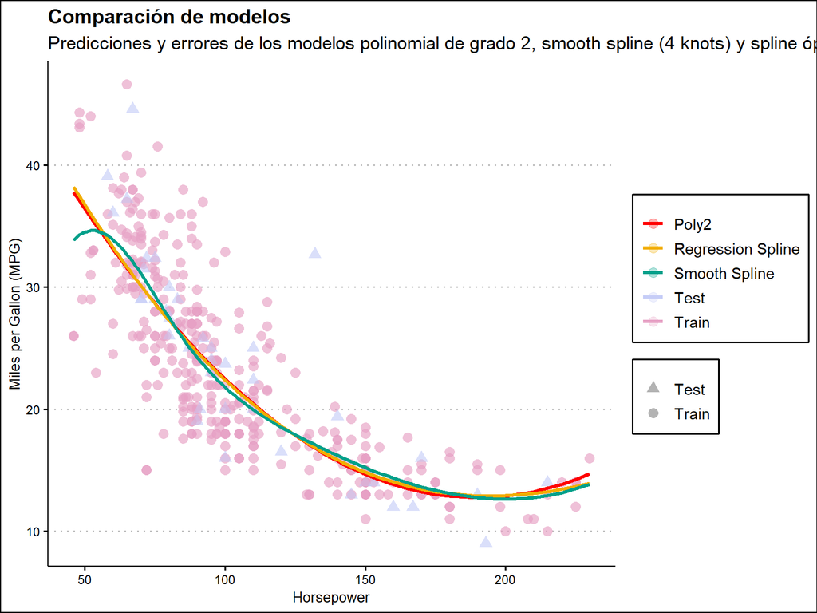

```r
library(ggthemes)
library(wesanderson)

# Fit de los modelos con todo el train_data
poly2_model <- lm(mpg ~ poly(horsepower, 2), data = train_data)
smooth_spline_model <- smooth.spline(train_data$horsepower, train_data$mpg, nknots = 4)
reg_spline_model <- lm(mpg ~ bs(horsepower, knots = optimal_num_knots, degree = 3), data = train_data)

# Hacemos predicciones para train_data and test_data
train_poly2_predictions <- predict(poly2_model, train_data)
test_poly2_predictions <- predict(poly2_model, test_data)

train_smooth_spline_predictions <- predict(smooth_spline_model, train_data$horsepower)$y
test_smooth_spline_predictions <- predict(smooth_spline_model, test_data$horsepower)$y

train_reg_spline_predictions <- predict(reg_spline_model, train_data)
test_reg_spline_predictions <- predict(reg_spline_model, test_data)

# Creamos un nuevo data frame con valores reales y valores predichos para cada modelo
plot_data <- rbind(
  cbind(train_data, Model = "Poly2", Prediction = train_poly2_predictions, Data = "Train"),
  cbind(test_data, Model = "Poly2", Prediction = test_poly2_predictions, Data = "Test"),
  cbind(train_data, Model = "Smooth Spline", Prediction = train_smooth_spline_predictions, Data = "Train"),
  cbind(test_data, Model = "Smooth Spline", Prediction = test_smooth_spline_predictions, Data = "Test"),
  cbind(train_data, Model = "Regression Spline", Prediction = train_reg_spline_predictions, Data = "Train"),
  cbind(test_data, Model = "Regression Spline", Prediction = test_reg_spline_predictions, Data = "Test")
)

# Graficar los modelos
ggplot(plot_data, aes(x = horsepower, y = mpg)) +
  geom_point(aes(shape = Data, color = Data), size = 3, alpha = 0.3) +
  geom_line(aes(y = Prediction, color = Model), linewidth = 1.2) +
  scale_color_manual(values = c("Train" = wes_palette("GrandBudapest2")[1], "Test" = wes_palette("GrandBudapest2")[2], "Poly2" = wes_palette("Darjeeling1")[1], "Smooth Spline" = wes_palette("Darjeeling1")[2], "Regression Spline" = wes_palette("Darjeeling1")[3])) +
  scale_shape_manual(values = c("Train" = 16, "Test" = 17)) +
  labs(title = "Comparación de modelos",
       subtitle = "Predicciones y errores de los modelos polinomial de grado 2, smooth spline (4 knots) y spline óptimo",
       x = "Horsepower",
       y = "Miles per Gallon (MPG)",
       color = "Data/Model",
       shape = "Data") +
  theme_clean() +
  theme(legend.title = element_blank())
```

## 1.4 Modelo basado en regresión local

```r
calculate_ecm_loess <- function(train_data, degree, fold, seed, visualize = FALSE) {
  set.seed(seed)
  train_index <- createFolds(train_data$mpg, k = fold, list = TRUE, returnTrain = TRUE)
  ecm_values <- numeric(fold)

  plot_data <- data.frame(horsepower = numeric(0), mpg = numeric(0), Model = character(0), Data = character(0))
  best_ecm <- Inf
  best_fold_predictions <- NULL
  best_x_seq <- NULL

  for (i in 1:fold) {
    train_fold <- train_data[train_index[[i]], ]
    test_fold <- train_data[-train_index[[i]], ]

    model <- loess(mpg ~ horsepower, data = train_fold, degree = degree)

    in_range <- test_fold$horsepower >= min(train_fold$horsepower) &
                test_fold$horsepower <= max(train_fold$horsepower)
    test_fold_in_range <- test_fold[in_range, ]

    if (nrow(test_fold_in_range) == 0) {
      cat("Skipping fold", i, "Por que los datos estan fuera del rango.\n")
      ecm_values[i] <- NA
    } else {
      predictions <- predict(model, test_fold_in_range)
      ecm <- mean((test_fold_in_range$mpg - predictions)^2)
      ecm_values[i] <- ecm

      if (visualize && ecm < best_ecm) {
        best_ecm <- ecm
        best_x_seq <- seq(min(train_fold$horsepower), max(train_fold$horsepower), length.out = 100)
        best_fold_predictions <- predict(model, newdata = data.frame(horsepower = best_x_seq))
      }
    }
  }

  if (visualize && !is.null(best_fold_predictions)) {
    plot_data <- rbind(plot_data, data.frame(horsepower = best_x_seq, mpg = best_fold_predictions, Model = paste0("Degree ", degree), Data = "Prediction"))
  }

  return(list(ecm = mean(ecm_values, na.rm = TRUE), plot_data = plot_data))
}

# Calculate ECM for local regression models with polynomial degrees 0, 1, and 2, and visualize the models
result_0 <- calculate_ecm_loess(train_data, 0, 10, seed, visualize = TRUE)
result_1 <- calculate_ecm_loess(train_data, 1, 10, seed, visualize = TRUE)
result_2 <- calculate_ecm_loess(train_data, 2, 10, seed, visualize = TRUE)
```

Visualización de la tabla comparativa

```r
local_regression_comparison <- data.frame(
  Degree = c(0, 1, 2),
  ECM = c(result_0$ecm, result_1$ecm, result_2$ecm)
)
# Create an interactive table
datatable(local_regression_comparison,
          options = list(pageLength = 10, lengthMenu = c(5, 10, 20, 50), dom = 't'),
          rownames = FALSE,
          caption = "ECM values for each local regression model") %>%
  formatRound(columns = "ECM", digits = 2)
```

| Degree | ECM |
| --- | --- |
| 0 | 26.6311466096822 |
| 1 | 19.3906653526536 |
| 2 | 19.5497359716086 |

Al comparr los modelos de regresión local de grados 0, 1 y 2, es evidente que la regresión local de grados 1 y 2 proporciona una mejora significativa en el poder predictivo del modelo, en comparación con el modelo de grado 0.

```r
# Determine the best model based on the lowest ECM
best_degree <- local_regression_comparison$Degree[which.min(local_regression_comparison$ECM)]
cat("El mejor modelo de regresión local basado en el ECM más bajo es el de grado polinómico:", best_degree)
```

```
## El mejor modelo de regresión local basado en el ECM más bajo es el de grado polinómico: 1
```

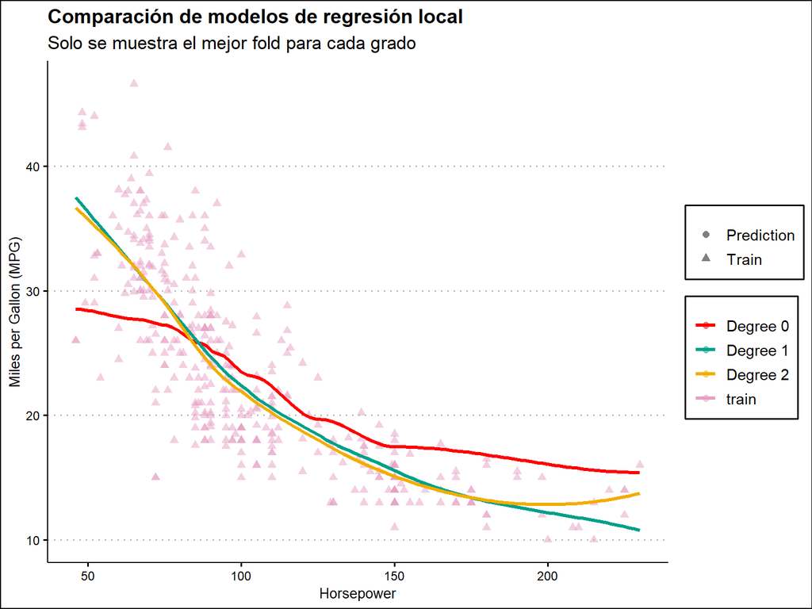

```r
# Combinar las gráficas
combined_plot_data <- rbind(result_0$plot_data, result_1$plot_data, result_2$plot_data)

# Se añaden los puntos de datos originales
train_plot_data <- data.frame(horsepower = train_data$horsepower, mpg = train_data$mpg, Model = "train", Data = "Train")
combined_plot_data <- rbind(combined_plot_data, train_plot_data)

# Define the color palettes
color_palette_data <- wes_palette("GrandBudapest2", 2, type = "discrete")  # 2 colors for "Train" and "Test"
color_palette_model <- wes_palette("Darjeeling1", 3, type = "discrete")  # 3 colors for "Degree 0", "Degree 1", "Degree 2"

# Generate the plot
combined_plot <- ggplot(combined_plot_data, aes(x = horsepower, y = mpg, color = Model, shape = Data)) +
  geom_point(data = combined_plot_data[combined_plot_data$Data != "Prediction", ], size = 2, alpha=0.5) +
  geom_line(data = combined_plot_data[combined_plot_data$Data == "Prediction", ], linewidth = 1.2) +
  scale_color_manual(values = c(color_palette_model, color_palette_data)) +
  scale_shape_manual(values = c(16, 17)) +
  labs(title = "Comparación de modelos de regresión local",
       subtitle = "Solo se muestra el mejor fold para cada grado",
       x = "Horsepower",
       y = "Miles per Gallon (MPG)",
       color = "Model",
       shape = "Data") +
  theme_clean() +
  theme(legend.title = element_blank())

# Print the plot
print(combined_plot)
```

## 1.5 y 1.6 comparación de paradigmas

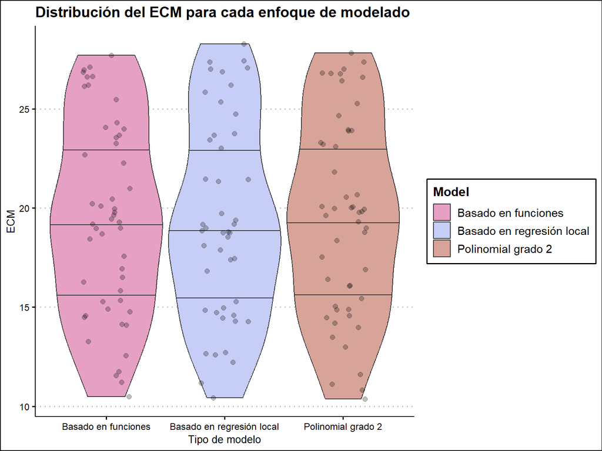

```r
# Inicializar el vector para guarar los resultados del ECM
ecm_values <- data.frame(Model = character(), ECM = numeric())

# Repetir 50 veces
for (i in 1:50) {

   # División de los datos
   index <- createDataPartition(Auto$mpg, p = 0.9, list = FALSE)
   train_data <- Auto[index, ]
   test_data <- Auto[-index, ]

   # Modelo de regresión en base de funciones
   spline_model <- smooth.spline(train_data$horsepower, train_data$mpg, df = 4)

   # Calculo del ECM para basado en funciones
   spline_predictions <- predict(spline_model, test_data$horsepower)$y
   ecm_spline <- mean((test_data$mpg - spline_predictions)^2)
   ecm_values <- rbind(ecm_values, data.frame(Model = "Basado en funciones", ECM = ecm_spline))

   # Basado en regresión local
   loess_model <- loess(mpg ~ horsepower, degree = 2, data = train_data)

   # Calculo del ECM para regresión local
   loess_predictions <- predict(loess_model, degree = 2, newdata = test_data)
   ecm_loess <- mean((test_data$mpg - loess_predictions)^2)
   ecm_values <- rbind(ecm_values, data.frame(Model = "Basado en regresión local", ECM = ecm_loess))

   # Modelo Polinomial
   polynomial_model <- lm(mpg ~ poly(horsepower, 2), data = train_data)  # polynomial of degree 2

   # ECM Polinomial
   polynomial_predictions <- predict(polynomial_model, newdata = test_data)
   ecm_polynomial <- mean((test_data$mpg - polynomial_predictions)^2)
   ecm_values <- rbind(ecm_values, data.frame(Model = "Polinomial grado 2", ECM = ecm_polynomial))
}

# Paleta de colores
wes_palette <- wesanderson::wes_palette("GrandBudapest2")

# Gráfico
ggplot(ecm_values, aes(x = Model, y = ECM, fill = Model)) +
  geom_violin(scale = "width", adjust = 1, width = 0.95, draw_quantiles = c(0.25, 0.5, 0.75)) +
  geom_jitter(width = 0.2, size = 2, shape = 21, fill = 'black', alpha = 0.25) +
  scale_fill_manual(values = wes_palette) +
  labs(title = "Distribución del ECM para cada enfoque de modelado",
       x = "Tipo de modelo",
       y = "ECM") +
  theme_clean()
```

Resulta evidente que el Error Cuadrático Medio (ECM) obtenido para cada uno de los tres modelos —basado en funciones, regresión local y Polinomial— son relativamente cercanos entre sí, es decir tienen un rendimiento similar en el poder predictivo.

Sin embargo, **al analizar en detalle los valores del ECM, se puede observar que el modelo regresión local tiende a tener un rendimiento ligeramente mejor que los otros dos modelos**. Este enfoque, parece ser capaz de capturar con mayor precisión las relaciones no lineales en el conjunto de datos.

En contraste, el modelo polinomial, que impone una estructura específica en los datos (en este caso, una relación cuadrática), tiende a tener un ECM ligeramente mayor. Claramente la relación real entre la potencia del vehículo y el consumo de combustible no se ajusta perfectamente a una relación cuadrática.

En algunas iteraciones el modelo de regresión local no fue capaz de arrojar una predicción, lo que podría indicar que se trata de un enfoque menos robusto, dado que las ganacias en desempeño son relativamente marginales **si se tratará de un ambiente de producción escogeriamos el** **modelo polinomial de grado 2**.

```r
ecm_median_values <- ecm_values %>% group_by(Model) %>% summarise(median = median(ECM, na.rm = TRUE))
datatable(ecm_median_values, rownames = FALSE, caption = "Mediana del ECM para cada paradigma") %>%
  formatRound(columns = "median", digits = 2)
```

| Model | median |
| --- | --- |
| Basado en funciones | 19.3661179769712 |
| Basado en regresión local | 18.820883591075 |
| Polinomial grado 2 | 19.7986883683183 |

# 2. Problema 2 - 20pt

## 2.1 El estimador de Nadaraya-Watson

```r
# Cargar las bibliotecas necesarias
library(KernSmooth)
# Establecer la semilla para la reproducibilidad
set.seed(42)

# Generar datos sintéticos
n <- 100
t <- seq(0, 1, length.out = n)
true_function <- function(t) {sin(pi * t)}
noise <- rnorm(n, mean = 0, sd = 0.2)
y <- true_function(t) + noise

# Implementar el estimador de Nadaraya-Watson para una única unidad estadística
nadarya_watson_estimator <- function(x, t, t_i, h) {
  kernel_weights <- dnorm(t - t_i, mean = 0, sd = h)
  return(sum(x * kernel_weights) / sum(kernel_weights))
}
# Implementar el estimador de Nadaraya-Watson completo
nadwat_est <- function(t_values, x, t, bandwidth) {
  x_t <- numeric(length(t_values))
  for (i in 1:length(t_values)) {
    t_val <- t_values[i]
    x_t[i] <- nadarya_watson_estimator(x, t, t_val, bandwidth)
  }
  return(x_t)
}

# Estimar la función de regresión utilizando el estimador de Nadaraya-Watson
bandwidth <- dpill(y, t)  # Estimar el ancho de banda óptimo
estimated_function <- nadwat_est(t, y, t, bandwidth = bandwidth)
```

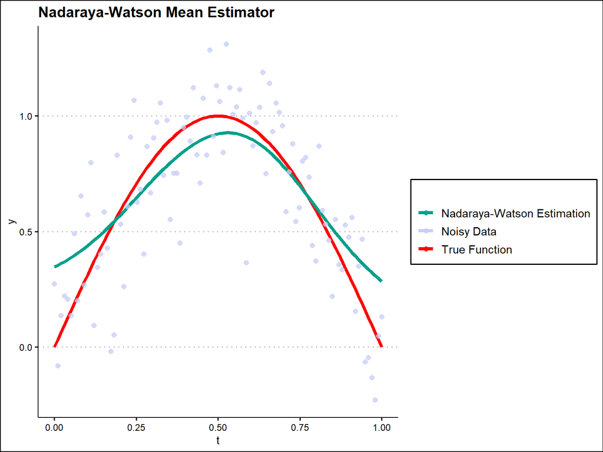

```r
# Guardar los resultados
df <- data.frame(t = t, y = y, True_Function = true_function(t), Nadaraya_Watson_Estimation = estimated_function)

# Establecer las paletas de colores
data_palette <- wes_palette("GrandBudapest2")
line_palette <- wes_palette("Darjeeling1")

# Graficar la función verdadera y la función estimada
ggplot(df, aes(x = t)) +
  geom_line(aes(y = True_Function, color = "True Function"), size = 1.5, linetype = "solid", show.legend = TRUE) +
  geom_line(aes(y = Nadaraya_Watson_Estimation, color = "Nadaraya-Watson Estimation"), size = 1.5, show.legend = TRUE) +
  geom_point(aes(y = y, color = "Noisy Data"), size = 2, alpha = 0.75, show.legend = TRUE) +
  scale_color_manual(name = "", values = c("Noisy Data" = data_palette[2], "True Function" = line_palette[1], "Nadaraya-Watson Estimation" = line_palette[2])) +
  labs(x = "t", y = "y", title = "Nadaraya-Watson Mean Estimator") +
  theme_clean()
```

En este caso, el estimador de Nadarya-Watson se ha utilizado para estimar la función de regresión para datos sintéticos generados a partir de una función seno y ruido gaussiano. La función se ha estimado utilizando el ancho de banda óptimo estimado con dpill.

La estimación para un valor específico i se ha obtenido utilizando el estimador de Nadarya-Watson para calcular el valor i en la variable independiente t. La función kernel utilizada es la función gaussiana estándar dnorm.

La implementación del estimador de Nadaraya-Watson en los datos sintéticos ha demostrado ser efectiva para recuperar la función subyacente. A pesar de la presencia de ruido en los datos, el estimador ha logrado capturar la forma general de la función verdadera.

## 2.2 El estimador de Nadaraya-Watson para la funcion media en t

El estimador de Nadaraya-Watson para la función media µ(t) es muy similar al estimador para una única unidad estadística. La principal diferencia es que, en lugar de estimar la función para una sola unidad, se utiliza el conjunto completo de datos discretizados para estimar la función media.